# Lab 3

   ```
   ## # A tibble: 40 x 3
   ## # Groups:   marital [5]
   ##    marital       party              perc_happy
   ##    <fct>         <fct>                   <dbl>
   ##  1 Never married Strong democrat         0.826
   ##  2 Never married Not str democrat        0.843
   ##  3 Never married Ind,near dem            0.830
   ##  4 Never married Independent             0.804
   ##  5 Never married Ind,near rep            0.844
   ##  6 Never married Not str republican      0.891
   ##  7 Never married Strong republican       0.887
   ##  8 Never married Other party             0.762
   ##  9 Married       Strong democrat         0.906
   ## 10 Married       Not str democrat        0.916
   ## # ... with 30 more rows
   ```

   ```
   ## # A tibble: 6 x 2
   ##   marital       mean_educ
   ##   <fct>             <dbl>
   ## 1 No answer          15.5
   ## 2 Never married      13.4
   ## 3 Married            13.0
   ## 4 Separated          11.9
   ## 5 Divorced           13.1
   ## 6 Widowed            11.2
   ```

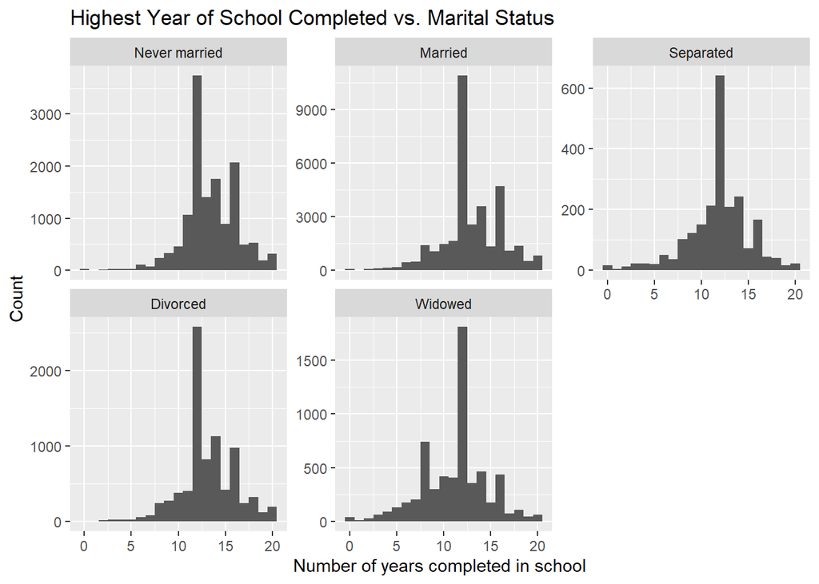

   The histograms above appear to show that regardless of marital status, the distribution of number of years completed in school is relatively the same. Widowed and separated have the widest range of number of years completed in school. Based on the table, those who chose not to answer completed the highest years of education with an average of 15.5 years, followed by never married, divorced, married, separated, then widowed.

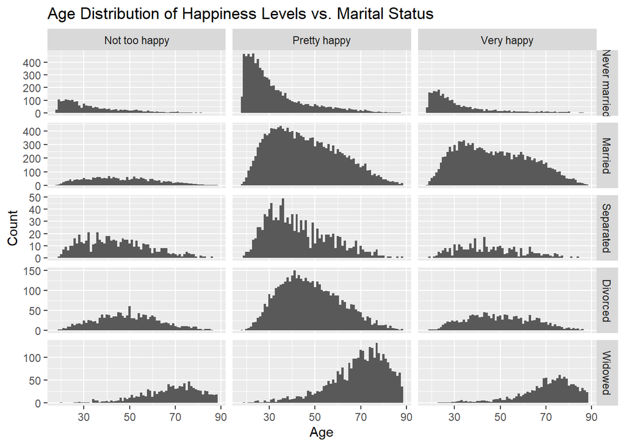

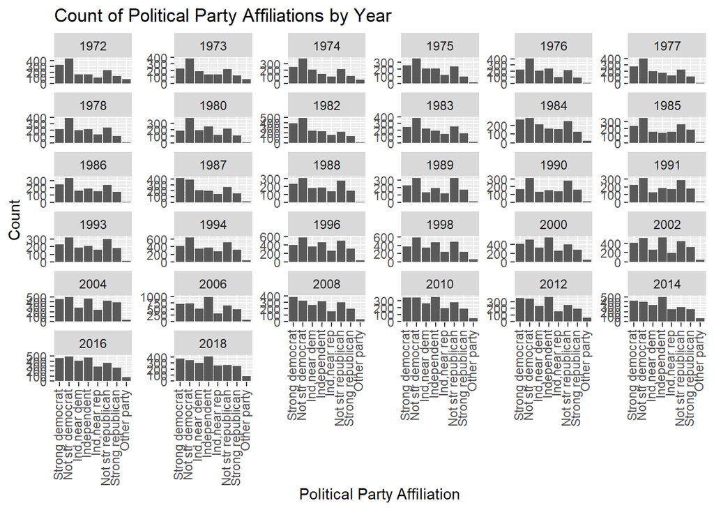

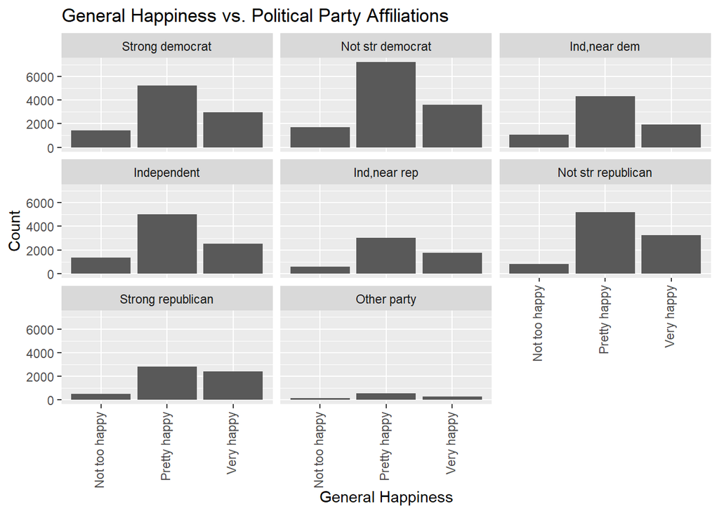

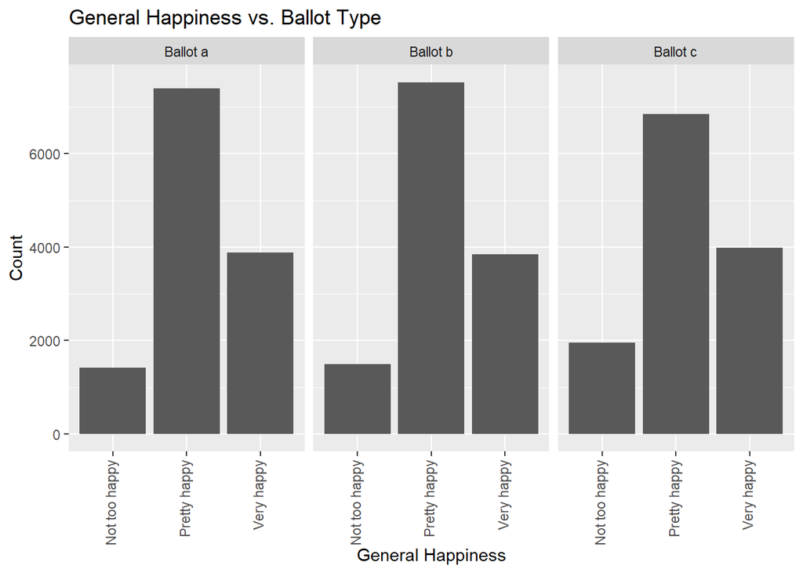

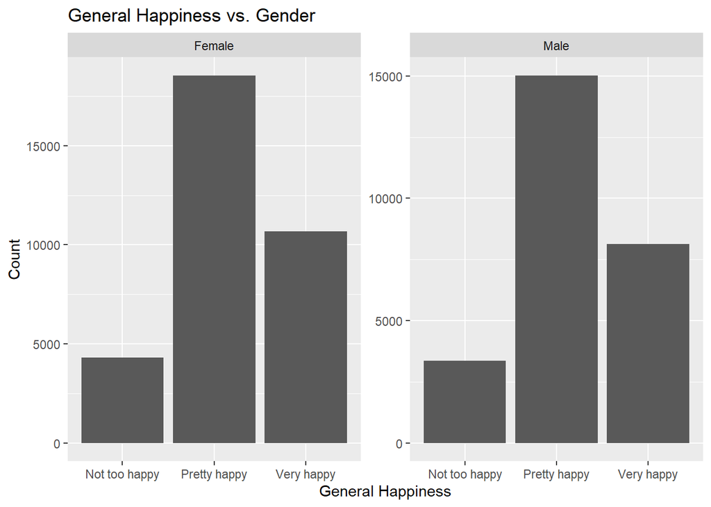

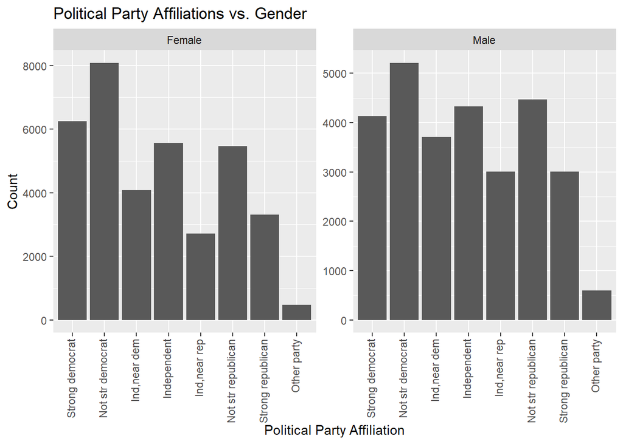

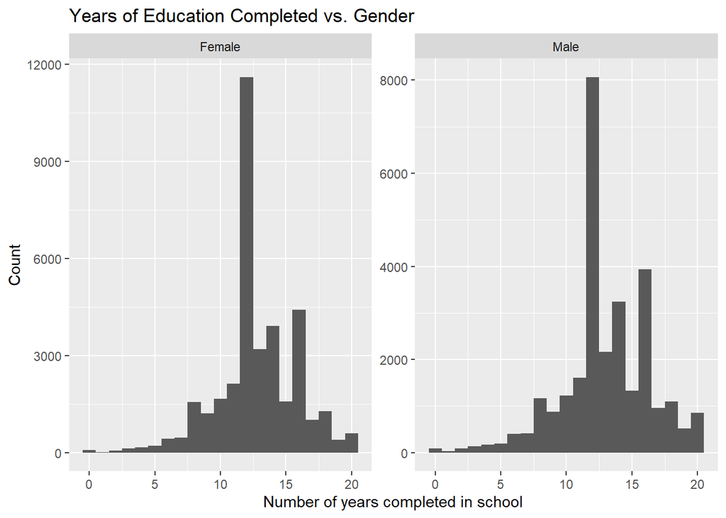

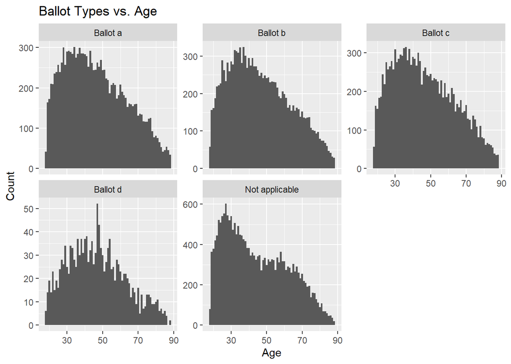

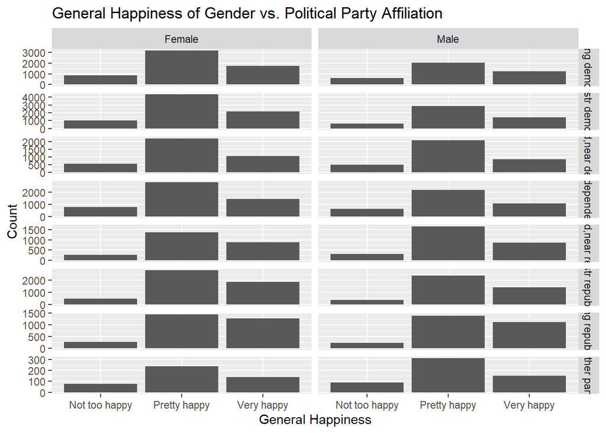

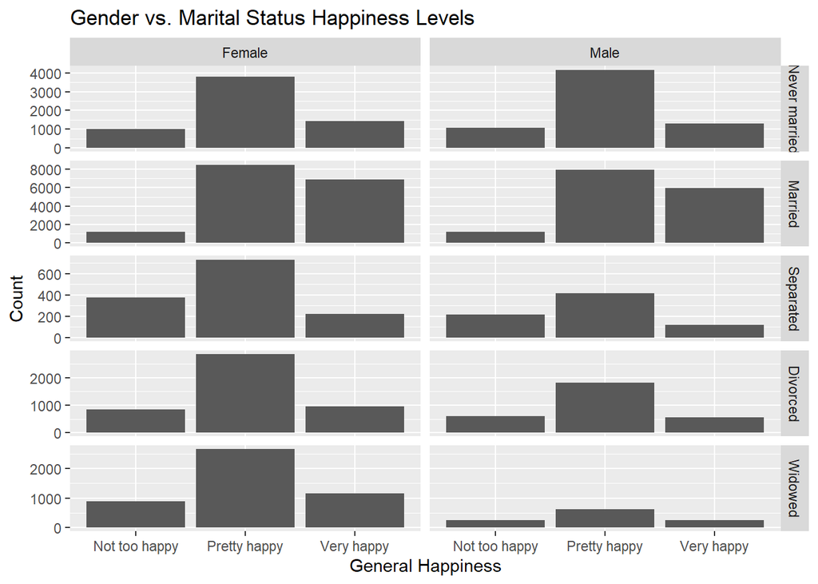